# aula03 :: PostgreSQL + R

Ricardo da Silveira Filho

10 abr 2021

### 0) Setup

- Carregando os pacotes a serem utilizados na sessão

```r
library(DBI)
library(lubridate)
library(RPostgres)
library(stf)
library(tidyverse)
```

### 1) `tidyverse` (continuação)

- Construindo Dataframes

```r
# Criando data.frame com rbase
df <- data.frame(col1 = c("a", "b", "c"),
                 col2 = c(1, 2, 3))
# Estrutura
str(df)
```

```
## 'data.frame':    3 obs. of  2 variables:
##  $ col1: chr  "a" "b" "c"
##  $ col2: num  1 2 3
```

```r
# Criando data.frame com tibble
df_tibble <- tibble(col1 = c("a", "b", "c"),
                 col2 = c(1, 2, 3))

# Estrutura
glimpse(df_tibble)
```

```
## Rows: 3
## Columns: 2
## $ col1 <chr> "a", "b", "c"
## $ col2 <dbl> 1, 2, 3
```

```r
# Adicionando linha
df_tibble <- df_tibble %>%
    add_row(col1 = "d", col2 = 4)

glimpse(df_tibble)
```

```
## Rows: 4
## Columns: 2
## $ col1 <chr> "a", "b", "c", "d"
## $ col2 <dbl> 1, 2, 3, 4
```

```r
# Adicionando coluna
df_tibble <- df_tibble %>%
    add_column(col0 = 5:8, .before = 1)

glimpse(df_tibble)
```

```
## Rows: 4
## Columns: 3
## $ col0 <int> 5, 6, 7, 8
## $ col1 <chr> "a", "b", "c", "d"
## $ col2 <dbl> 1, 2, 3, 4
```

### 2) dplyr

- Baixando o banco de dados

```r
# Baixando banco de dados
incid <- 2635061:2635161

stf_download_information(incidente = incid,
                         dir = here::here("data", "exdplyr", "informacoes"))
stf_download_parties(incid, here::here("data", "exdplyr", "partes"))
stf_download_details(incid, here::here("data", "exdplyr", "detalhes"))
stf_download_sheet(incid, here::here("data", "exdplyr", "movimentacao"))
```

- Colocando em objetos

```r
informacoes <- read_stf_information(path = here::here("data", "exdplyr", "informacoes"))
informacoes
partes <- read_stf_parties(path = here::here("data", "exdplyr", "partes"))
partes
detalhes <- read_stf_details(path = here::here("data", "exdplyr", "detalhes"))
detalhes
movimentacao <- read_stf_docket_sheet(path = here::here("data", "exdplyr", "movimentacao"))
movimentacao
```

- Salvando Base de Dados STF

```r
save(detalhes, informacoes, movimentacao, partes, file = here::here("data", "exdplyr", "base_stf.rda"))
```

- Carregando Base de Dados STF

```r
load(file = here::here("data", "exdplyr", "base_stf.rda"))
```

- `count()`
  - Contabilizando observações

```r
# Utilizando uma variável
detalhes %>%
    count(relator_atual, sort = TRUE)
```

```
## # A tibble: 15 x 2
##    relator_atual                n
##    <chr>                    <int>
##  1 MIN. AYRES BRITTO           14
##  2 MIN. CELSO DE MELLO         13
##  3 MIN. CEZAR PELUSO           12
##  4 MINISTRO PRESIDENTE         11
##  5 MIN. CÁRMEN LÚCIA            9
##  6 MIN. EROS GRAU               9
##  7 MIN. MARCO AURÉLIO           8
##  8 MIN. RICARDO LEWANDOWSKI     8
##  9 MIN. JOAQUIM BARBOSA         5
## 10 MIN. ELLEN GRACIE            4
## 11 MIN. MENEZES DIREITO         3
## 12 MIN. GILMAR MENDES           2
## 13 MIN. DIAS TOFFOLI            1
## 14 MIN. LUIZ FUX                1
## 15 MIN. TEORI ZAVASCKI          1
```

```r
# Mais de uma variável
detalhes %>%
    count(relator_atual, classe, sort = TRUE)
```

```
## # A tibble: 38 x 3
##    relator_atual       classe     n
##    <chr>               <chr>  <int>
##  1 MINISTRO PRESIDENTE AI        11
##  2 MIN. AYRES BRITTO   RE         8
##  3 MIN. CEZAR PELUSO   RE         6
##  4 MIN. AYRES BRITTO   AI         5
##  5 MIN. CELSO DE MELLO RE         5
##  6 MIN. MARCO AURÉLIO  AI         5
##  7 MIN. CÁRMEN LÚCIA   RE         4
##  8 MIN. CELSO DE MELLO AI         4
##  9 MIN. CEZAR PELUSO   AI         4
## 10 MIN. EROS GRAU      AI         4
## # … with 28 more rows
```

```r
# Equivalente a:
detalhes %>%
    group_by(relator_atual, classe) %>%
    summarise(n = n(),
              .groups = "drop")
```

```
## # A tibble: 38 x 3
##    relator_atual       classe     n
##    <chr>               <chr>  <int>
##  1 MIN. AYRES BRITTO   AI         5
##  2 MIN. AYRES BRITTO   HC         1
##  3 MIN. AYRES BRITTO   RE         8
##  4 MIN. CÁRMEN LÚCIA   AI         2
##  5 MIN. CÁRMEN LÚCIA   HC         2
##  6 MIN. CÁRMEN LÚCIA   MS         1
##  7 MIN. CÁRMEN LÚCIA   RE         4
##  8 MIN. CELSO DE MELLO AI         4
##  9 MIN. CELSO DE MELLO HC         1
## 10 MIN. CELSO DE MELLO MS         1
## # … with 28 more rows
```

- `filter()`
  - Filtrando observações (linhas)

```r
# Somente um filtro
detalhes %>%
    filter(classe == "AI")
```

```
## # A tibble: 40 x 7
##    incidente meio          sigilo  numero_unico classe numero relator_atual
##    <chr>     <chr>         <chr>   <chr>        <chr>  <chr>  <chr>
##  1 2635061   Processo Fís… Público <NA>         AI     725002 MIN. CÁRMEN LÚCIA
##  2 2635062   Processo Fís… Público <NA>         AI     725006 MIN. CELSO DE MEL…
##  3 2635063   Processo Fís… Público <NA>         AI     725007 MIN. MENEZES DIRE…
##  4 2635067   Processo Fís… Público <NA>         AI     725005 MIN. CELSO DE MEL…
##  5 2635068   Processo Fís… Público <NA>         AI     725011 MIN. AYRES BRITTO
##  6 2635069   Processo Fís… Público <NA>         AI     725013 MIN. AYRES BRITTO
##  7 2635070   Processo Fís… Público <NA>         AI     725018 MIN. AYRES BRITTO
##  8 2635078   Processo Fís… Público <NA>         AI     725080 MINISTRO PRESIDEN…
##  9 2635083   Processo Fís… Público <NA>         AI     725068 MIN. LUIZ FUX
## 10 2635086   Processo Fís… Público <NA>         AI     725079 MINISTRO PRESIDEN…
## # … with 30 more rows
```

```r
# Utilizando "OU"
detalhes %>%
    filter(classe == "AI" | classe == "HC")
```

```
## # A tibble: 53 x 7
##    incidente meio      sigilo  numero_unico      classe numero relator_atual
##    <chr>     <chr>     <chr>   <chr>             <chr>  <chr>  <chr>
##  1 2635061   Processo… Público <NA>              AI     725002 MIN. CÁRMEN LÚCIA
##  2 2635062   Processo… Público <NA>              AI     725006 MIN. CELSO DE ME…
##  3 2635063   Processo… Público <NA>              AI     725007 MIN. MENEZES DIR…
##  4 2635064   Processo… Público 0004754-72.2008.… HC     95900  MIN. ELLEN GRACIE
##  5 2635067   Processo… Público <NA>              AI     725005 MIN. CELSO DE ME…
##  6 2635068   Processo… Público <NA>              AI     725011 MIN. AYRES BRITTO
##  7 2635069   Processo… Público <NA>              AI     725013 MIN. AYRES BRITTO
##  8 2635070   Processo… Público <NA>              AI     725018 MIN. AYRES BRITTO
##  9 2635071   Processo… Público 0004757-27.2008.… HC     95884  MIN. RICARDO LEW…
## 10 2635072   Processo… Público 0004758-12.2008.… HC     95888  MIN. ELLEN GRACIE
## # … with 43 more rows
```

```r
# Utilizando "E"
detalhes %>%
    filter(classe == "HC" & relator_atual == "MIN. CELSO DE MELLO")
```

```
## # A tibble: 1 x 7
##   incidente meio       sigilo  numero_unico       classe numero relator_atual
##   <chr>     <chr>      <chr>   <chr>              <chr>  <chr>  <chr>
## 1 2635073   Processo … Público 0004759-94.2008.0… HC     95897  MIN. CELSO DE M…
```

- `select()`
  - Selecionando colunas

```r
# Somente uma variável
informacoes %>%
    select(incidente)
```

```
## # A tibble: 101 x 1
##    incidente
##    <chr>
##  1 2635061
##  2 2635062
##  3 2635063
##  4 2635064
##  5 2635065
##  6 2635066
##  7 2635067
##  8 2635068
##  9 2635069
## 10 2635070
## # … with 91 more rows
```

```r
# Mais de uma variável
informacoes %>%
    select(incidente, origem)
```

```
## # A tibble: 101 x 2
##    incidente origem
##    <chr>     <chr>
##  1 2635061   PERNAMBUCO
##  2 2635062   RIO GRANDE DO SUL
##  3 2635063   RIO GRANDE DO SUL
##  4 2635064   SÃO PAULO
##  5 2635065   DISTRITO FEDERAL
##  6 2635066   RIO DE JANEIRO
##  7 2635067   MINAS GERAIS
##  8 2635068   MINAS GERAIS
##  9 2635069   RIO DE JANEIRO
## 10 2635070   SÃO PAULO
## # … with 91 more rows
```

```r
# Pelo índice
informacoes %>%
    select(1)
```

```
## # A tibble: 101 x 1
##    incidente
##    <chr>
##  1 2635061
##  2 2635062
##  3 2635063
##  4 2635064
##  5 2635065
##  6 2635066
##  7 2635067
##  8 2635068
##  9 2635069
## 10 2635070
## # … with 91 more rows
```

```r
# Três primeiras variáveis
informacoes %>%
    select(1:3)
```

```
## # A tibble: 101 x 3
##    incidente assunto1                          assunto2
##    <chr>     <chr>                             <chr>
##  1 2635061   "DIREITO PROCESSUAL CIVIL E DO T… "DIREITO PROCESSUAL CIVIL E DO T…
##  2 2635062   "DIREITO ADMINISTRATIVO E OUTRAS… "DIREITO PROCESSUAL CIVIL E DO T…
##  3 2635063   "DIREITO PENAL | Parte Geral | T…  <NA>
##  4 2635064   "DIREITO PROCESSUAL PENAL | Ação…  <NA>
##  5 2635065   "DIREITO ADMINISTRATIVO E OUTRAS…  <NA>
##  6 2635066   "DIREITO ADMINISTRATIVO E OUTRAS…  <NA>
##  7 2635067   "DIREITO ADMINISTRATIVO E OUTRAS…  <NA>
##  8 2635068   "DIREITO CIVIL | Obrigações | In… "DIREITO TRIBUTÁRIO | Contribuiç…
##  9 2635069   "DIREITO TRIBUTÁRIO | Impostos |… "DIREITO TRIBUTÁRIO | Crédito Tr…
## 10 2635070   "DIREITO PROCESSUAL CIVIL E DO T…  <NA>
## # … with 91 more rows
```

```r
informacoes %>%
    select(incidente:assunto2)
```

```
## # A tibble: 101 x 3
##    incidente assunto1                          assunto2
##    <chr>     <chr>                             <chr>
##  1 2635061   "DIREITO PROCESSUAL CIVIL E DO T… "DIREITO PROCESSUAL CIVIL E DO T…
##  2 2635062   "DIREITO ADMINISTRATIVO E OUTRAS… "DIREITO PROCESSUAL CIVIL E DO T…
##  3 2635063   "DIREITO PENAL | Parte Geral | T…  <NA>
##  4 2635064   "DIREITO PROCESSUAL PENAL | Ação…  <NA>
##  5 2635065   "DIREITO ADMINISTRATIVO E OUTRAS…  <NA>
##  6 2635066   "DIREITO ADMINISTRATIVO E OUTRAS…  <NA>
##  7 2635067   "DIREITO ADMINISTRATIVO E OUTRAS…  <NA>
##  8 2635068   "DIREITO CIVIL | Obrigações | In… "DIREITO TRIBUTÁRIO | Contribuiç…
##  9 2635069   "DIREITO TRIBUTÁRIO | Impostos |… "DIREITO TRIBUTÁRIO | Crédito Tr…
## 10 2635070   "DIREITO PROCESSUAL CIVIL E DO T…  <NA>
## # … with 91 more rows
```

```r
# Retirar variável(is) de um banco de dados
informacoes %>%
    select(-assunto2)
```

```
## # A tibble: 101 x 8
##    incidente assunto1  assunto3 data_protocolo orgao_origem origem numero_origem
##    <chr>     <chr>     <chr>    <date>         <chr>        <chr>  <chr>
##  1 2635061   "DIREITO… <NA>     2008-08-22     SUPERIOR TR… PERNA… 930239
##  2 2635062   "DIREITO… DIREITO… 2008-08-22     TRIBUNAL DE… RIO G… 70020152765
##  3 2635063   "DIREITO… <NA>     2008-08-22     TRIBUNAL DE… RIO G… 71001656644
##  4 2635064   "DIREITO… <NA>     2008-08-22     SUPREMO TRI… SÃO P… 116210
##  5 2635065   "DIREITO… <NA>     2008-08-22     SUPREMO TRI… DISTR… 115761
##  6 2635066   "DIREITO… <NA>     2008-08-22     JUIZ FEDERAL RIO D… 200851010112…
##  7 2635067   "DIREITO… <NA>     2008-08-22     TRIBUNAL DE… MINAS… 239151400
##  8 2635068   "DIREITO… <NA>     2008-08-22     TRIBUNAL DE… MINAS… 100240441142…
##  9 2635069   "DIREITO… DIREITO… 2008-08-22     TRIBUNAL DE… RIO D… 200700123375
## 10 2635070   "DIREITO… <NA>     2008-08-22     TRIBUNAL RE… SÃO P… 200461040002…
## # … with 91 more rows, and 1 more variable: procedencia <chr>
```

```r
informacoes %>%
    select(-c(assunto1, assunto2, assunto3))
```

```
## # A tibble: 101 x 6
##    incidente data_protocolo orgao_origem    origem   numero_origem  procedencia
##    <chr>     <date>         <chr>           <chr>    <chr>          <chr>
##  1 2635061   2008-08-22     SUPERIOR TRIBU… PERNAMB… 930239         PE - PERNAM…
##  2 2635062   2008-08-22     TRIBUNAL DE JU… RIO GRA… 70020152765    RS - RIO GR…
##  3 2635063   2008-08-22     TRIBUNAL DE JU… RIO GRA… 71001656644    RS - RIO GR…
##  4 2635064   2008-08-22     SUPREMO TRIBUN… SÃO PAU… 116210         SP - SÃO PA…
##  5 2635065   2008-08-22     SUPREMO TRIBUN… DISTRIT… 115761         DF - DISTRI…
##  6 2635066   2008-08-22     JUIZ FEDERAL    RIO DE … 2008510101121… RJ - RIO DE…
##  7 2635067   2008-08-22     TRIBUNAL DE JU… MINAS G… 239151400      MG - MINAS …
##  8 2635068   2008-08-22     TRIBUNAL DE JU… MINAS G… 1002404411421… MG - MINAS …
##  9 2635069   2008-08-22     TRIBUNAL DE JU… RIO DE … 200700123375   RJ - RIO DE…
## 10 2635070   2008-08-22     TRIBUNAL REGIO… SÃO PAU… 2004610400022… SP - SÃO PA…
## # … with 91 more rows
```

```r
# Variáveis que começam com "X"
informacoes %>%
    select(starts_with("assunto"))
```

```
## # A tibble: 101 x 3
##    assunto1                  assunto2                  assunto3
##    <chr>                     <chr>                     <chr>
##  1 "DIREITO PROCESSUAL CIVI… "DIREITO PROCESSUAL CIVI… <NA>
##  2 "DIREITO ADMINISTRATIVO … "DIREITO PROCESSUAL CIVI… DIREITO PROCESSUAL CIVIL…
##  3 "DIREITO PENAL | Parte G…  <NA>                     <NA>
##  4 "DIREITO PROCESSUAL PENA…  <NA>                     <NA>
##  5 "DIREITO ADMINISTRATIVO …  <NA>                     <NA>
##  6 "DIREITO ADMINISTRATIVO …  <NA>                     <NA>
##  7 "DIREITO ADMINISTRATIVO …  <NA>                     <NA>
##  8 "DIREITO CIVIL | Obrigaç… "DIREITO TRIBUTÁRIO | Co… <NA>
##  9 "DIREITO TRIBUTÁRIO | Im… "DIREITO TRIBUTÁRIO | Cr… DIREITO TRIBUTÁRIO | Cré…
## 10 "DIREITO PROCESSUAL CIVI…  <NA>                     <NA>
## # … with 91 more rows
```

```r
# Variáveis que terminam com "X"
informacoes %>%
    select(ends_with("origem"))
```

```
## # A tibble: 101 x 3
##    orgao_origem                 origem            numero_origem
##    <chr>                        <chr>             <chr>
##  1 SUPERIOR TRIBUNAL DE JUSTIÇA PERNAMBUCO        930239
##  2 TRIBUNAL DE JUSTIÇA ESTADUAL RIO GRANDE DO SUL 70020152765
##  3 TRIBUNAL DE JUSTIÇA ESTADUAL RIO GRANDE DO SUL 71001656644
##  4 SUPREMO TRIBUNAL FEDERAL     SÃO PAULO         116210
##  5 SUPREMO TRIBUNAL FEDERAL     DISTRITO FEDERAL  115761
##  6 JUIZ FEDERAL                 RIO DE JANEIRO    200851010112180
##  7 TRIBUNAL DE JUSTIÇA ESTADUAL MINAS GERAIS      239151400
##  8 TRIBUNAL DE JUSTIÇA ESTADUAL MINAS GERAIS      10024044114213001
##  9 TRIBUNAL DE JUSTIÇA ESTADUAL RIO DE JANEIRO    200700123375
## 10 TRIBUNAL REGIONAL FEDERAL    SÃO PAULO         200461040002270
## # … with 91 more rows
```

```r
# Variáveis que contém "X"
informacoes %>%
    select(contains("origem"))
```

```
## # A tibble: 101 x 3
##    orgao_origem                 origem            numero_origem
##    <chr>                        <chr>             <chr>
##  1 SUPERIOR TRIBUNAL DE JUSTIÇA PERNAMBUCO        930239
##  2 TRIBUNAL DE JUSTIÇA ESTADUAL RIO GRANDE DO SUL 70020152765
##  3 TRIBUNAL DE JUSTIÇA ESTADUAL RIO GRANDE DO SUL 71001656644
##  4 SUPREMO TRIBUNAL FEDERAL     SÃO PAULO         116210
##  5 SUPREMO TRIBUNAL FEDERAL     DISTRITO FEDERAL  115761
##  6 JUIZ FEDERAL                 RIO DE JANEIRO    200851010112180
##  7 TRIBUNAL DE JUSTIÇA ESTADUAL MINAS GERAIS      239151400
##  8 TRIBUNAL DE JUSTIÇA ESTADUAL MINAS GERAIS      10024044114213001
##  9 TRIBUNAL DE JUSTIÇA ESTADUAL RIO DE JANEIRO    200700123375
## 10 TRIBUNAL REGIONAL FEDERAL    SÃO PAULO         200461040002270
## # … with 91 more rows
```

- Tutorial de expressões regulares (regex)
  - https://direito.consudata.com.br/shiny/stringr/

```r
# Utilizando regex
#   ex.: Selecionando variáveis que tenham números
informacoes %>%
    select(matches("\\d"))
```

```
## # A tibble: 101 x 3
##    assunto1                  assunto2                  assunto3
##    <chr>                     <chr>                     <chr>
##  1 "DIREITO PROCESSUAL CIVI… "DIREITO PROCESSUAL CIVI… <NA>
##  2 "DIREITO ADMINISTRATIVO … "DIREITO PROCESSUAL CIVI… DIREITO PROCESSUAL CIVIL…
##  3 "DIREITO PENAL | Parte G…  <NA>                     <NA>
##  4 "DIREITO PROCESSUAL PENA…  <NA>                     <NA>
##  5 "DIREITO ADMINISTRATIVO …  <NA>                     <NA>
##  6 "DIREITO ADMINISTRATIVO …  <NA>                     <NA>
##  7 "DIREITO ADMINISTRATIVO …  <NA>                     <NA>
##  8 "DIREITO CIVIL | Obrigaç… "DIREITO TRIBUTÁRIO | Co… <NA>
##  9 "DIREITO TRIBUTÁRIO | Im… "DIREITO TRIBUTÁRIO | Cr… DIREITO TRIBUTÁRIO | Cré…
## 10 "DIREITO PROCESSUAL CIVI…  <NA>                     <NA>
## # … with 91 more rows
```

- `arrange()`
  - Ordenando as observações

```r
# Ordem alfabética
detalhes %>%
    arrange(relator_atual)
```

```
## # A tibble: 101 x 7
##    incidente meio       sigilo  numero_unico       classe numero relator_atual
##    <chr>     <chr>      <chr>   <chr>              <chr>  <chr>  <chr>
##  1 2635068   Processo … Público <NA>               AI     725011 MIN. AYRES BRI…
##  2 2635069   Processo … Público <NA>               AI     725013 MIN. AYRES BRI…
##  3 2635070   Processo … Público <NA>               AI     725018 MIN. AYRES BRI…
##  4 2635089   Processo … Público <NA>               RE     591805 MIN. AYRES BRI…
##  5 2635095   Processo … Público <NA>               RE     591826 MIN. AYRES BRI…
##  6 2635096   Processo … Público <NA>               RE     591828 MIN. AYRES BRI…
##  7 2635103   Processo … Público 0004772-93.2008.0… HC     95923  MIN. AYRES BRI…
##  8 2635113   Processo … Público <NA>               AI     725099 MIN. AYRES BRI…
##  9 2635116   Processo … Público <NA>               AI     725104 MIN. AYRES BRI…
## 10 2635128   Processo … Público <NA>               RE     591789 MIN. AYRES BRI…
## # … with 91 more rows
```

```r
# Inverter ordem
detalhes %>%
    arrange(desc(relator_atual))
```

```
## # A tibble: 101 x 7
##    incidente meio           sigilo  numero_unico classe numero relator_atual
##    <chr>     <chr>          <chr>   <chr>        <chr>  <chr>  <chr>
##  1 2635078   Processo Físi… Público <NA>         AI     725080 MINISTRO PRESIDE…
##  2 2635086   Processo Físi… Público <NA>         AI     725079 MINISTRO PRESIDE…
##  3 2635088   Processo Físi… Público <NA>         AI     725087 MINISTRO PRESIDE…
##  4 2635090   Processo Físi… Público <NA>         AI     725100 MINISTRO PRESIDE…
##  5 2635140   Processo Físi… Público <NA>         AI     725073 MINISTRO PRESIDE…
##  6 2635141   Processo Físi… Público <NA>         AI     725075 MINISTRO PRESIDE…
##  7 2635142   Processo Físi… Público <NA>         AI     725077 MINISTRO PRESIDE…
##  8 2635143   Processo Físi… Público <NA>         AI     725078 MINISTRO PRESIDE…
##  9 2635149   Processo Físi… Público <NA>         AI     725076 MINISTRO PRESIDE…
## 10 2635150   Processo Físi… Público <NA>         AI     725081 MINISTRO PRESIDE…
## # … with 91 more rows
```

- `mutate()`
  - Criar ou alterar variáveis

```r
# Pegando somente o "ano" de uma data
informacoes %>%
    mutate(ano_protocolo = year(data_protocolo))
```

```
## # A tibble: 101 x 10
##    incidente assunto1   assunto2   assunto3   data_protocolo orgao_origem origem
##    <chr>     <chr>      <chr>      <chr>      <date>         <chr>        <chr>
##  1 2635061   "DIREITO … "DIREITO … <NA>       2008-08-22     SUPERIOR TR… PERNA…
##  2 2635062   "DIREITO … "DIREITO … DIREITO P… 2008-08-22     TRIBUNAL DE… RIO G…
##  3 2635063   "DIREITO …  <NA>      <NA>       2008-08-22     TRIBUNAL DE… RIO G…
##  4 2635064   "DIREITO …  <NA>      <NA>       2008-08-22     SUPREMO TRI… SÃO P…
##  5 2635065   "DIREITO …  <NA>      <NA>       2008-08-22     SUPREMO TRI… DISTR…
##  6 2635066   "DIREITO …  <NA>      <NA>       2008-08-22     JUIZ FEDERAL RIO D…
##  7 2635067   "DIREITO …  <NA>      <NA>       2008-08-22     TRIBUNAL DE… MINAS…
##  8 2635068   "DIREITO … "DIREITO … <NA>       2008-08-22     TRIBUNAL DE… MINAS…
##  9 2635069   "DIREITO … "DIREITO … DIREITO T… 2008-08-22     TRIBUNAL DE… RIO D…
## 10 2635070   "DIREITO …  <NA>      <NA>       2008-08-22     TRIBUNAL RE… SÃO P…
## # … with 91 more rows, and 3 more variables: numero_origem <chr>,
## #   procedencia <chr>, ano_protocolo <dbl>
```

```r
# Criando uma variável em um local específico do tibble
informacoes %>%
    mutate(ano_protocolo = year(data_protocolo), .after = data_protocolo)
```

```
## # A tibble: 101 x 10
##    incidente assunto1     assunto2     assunto3     data_protocolo ano_protocolo
##    <chr>     <chr>        <chr>        <chr>        <date>                 <dbl>
##  1 2635061   "DIREITO PR… "DIREITO PR… <NA>         2008-08-22              2008
##  2 2635062   "DIREITO AD… "DIREITO PR… DIREITO PRO… 2008-08-22              2008
##  3 2635063   "DIREITO PE…  <NA>        <NA>         2008-08-22              2008
##  4 2635064   "DIREITO PR…  <NA>        <NA>         2008-08-22              2008
##  5 2635065   "DIREITO AD…  <NA>        <NA>         2008-08-22              2008
##  6 2635066   "DIREITO AD…  <NA>        <NA>         2008-08-22              2008
##  7 2635067   "DIREITO AD…  <NA>        <NA>         2008-08-22              2008
##  8 2635068   "DIREITO CI… "DIREITO TR… <NA>         2008-08-22              2008
##  9 2635069   "DIREITO TR… "DIREITO TR… DIREITO TRI… 2008-08-22              2008
## 10 2635070   "DIREITO PR…  <NA>        <NA>         2008-08-22              2008
## # … with 91 more rows, and 4 more variables: orgao_origem <chr>, origem <chr>,
## #   numero_origem <chr>, procedencia <chr>
```

```r
# Criando mais de uma variável
informacoes %>%
    mutate(ano_protocolo = year(data_protocolo),
           mes_protocolo = month(data_protocolo),
           dia_protocolo = wday(data_protocolo, label = TRUE, abbr = FALSE),
           .after = incidente)
```

```
## # A tibble: 101 x 12
##    incidente ano_protocolo mes_protocolo dia_protocolo assunto1     assunto2
##    <chr>             <dbl>         <dbl> <ord>         <chr>        <chr>
##  1 2635061            2008             8 Friday        "DIREITO PR… "DIREITO PR…
##  2 2635062            2008             8 Friday        "DIREITO AD… "DIREITO PR…
##  3 2635063            2008             8 Friday        "DIREITO PE…  <NA>
##  4 2635064            2008             8 Friday        "DIREITO PR…  <NA>
##  5 2635065            2008             8 Friday        "DIREITO AD…  <NA>
##  6 2635066            2008             8 Friday        "DIREITO AD…  <NA>
##  7 2635067            2008             8 Friday        "DIREITO AD…  <NA>
##  8 2635068            2008             8 Friday        "DIREITO CI… "DIREITO TR…
##  9 2635069            2008             8 Friday        "DIREITO TR… "DIREITO TR…
## 10 2635070            2008             8 Friday        "DIREITO PR…  <NA>
## # … with 91 more rows, and 6 more variables: assunto3 <chr>,
## #   data_protocolo <date>, orgao_origem <chr>, origem <chr>,
## #   numero_origem <chr>, procedencia <chr>
```

```r
# Utilizando `across`
    # ex.: Retirando a palavra "DIREITO" de algumas variáveis
        # AT
informacoes %>%
    mutate(across(assunto1:assunto3, .fns = ~str_remove(.x, "DIREITO")))
```

```
## # A tibble: 101 x 9
##    incidente assunto1   assunto2   assunto3   data_protocolo orgao_origem origem
##    <chr>     <chr>      <chr>      <chr>      <date>         <chr>        <chr>
##  1 2635061   " PROCESS… " PROCESS…  <NA>      2008-08-22     SUPERIOR TR… PERNA…
##  2 2635062   " ADMINIS… " PROCESS… " PROCESS… 2008-08-22     TRIBUNAL DE… RIO G…
##  3 2635063   " PENAL |…  <NA>       <NA>      2008-08-22     TRIBUNAL DE… RIO G…
##  4 2635064   " PROCESS…  <NA>       <NA>      2008-08-22     SUPREMO TRI… SÃO P…
##  5 2635065   " ADMINIS…  <NA>       <NA>      2008-08-22     SUPREMO TRI… DISTR…
##  6 2635066   " ADMINIS…  <NA>       <NA>      2008-08-22     JUIZ FEDERAL RIO D…
##  7 2635067   " ADMINIS…  <NA>       <NA>      2008-08-22     TRIBUNAL DE… MINAS…
##  8 2635068   " CIVIL |… " TRIBUTÁ…  <NA>      2008-08-22     TRIBUNAL DE… MINAS…
##  9 2635069   " TRIBUTÁ… " TRIBUTÁ… " TRIBUTÁ… 2008-08-22     TRIBUNAL DE… RIO D…
## 10 2635070   " PROCESS…  <NA>       <NA>      2008-08-22     TRIBUNAL RE… SÃO P…
## # … with 91 more rows, and 2 more variables: numero_origem <chr>,
## #   procedencia <chr>
```

```r
    # ex.: Mudando em TODAS as variáveis
        # ALL
informacoes %>%
    mutate(across(.fns = as.character))
```

```
## # A tibble: 101 x 9
##    incidente assunto1   assunto2   assunto3   data_protocolo orgao_origem origem
##    <chr>     <chr>      <chr>      <chr>      <chr>          <chr>        <chr>
##  1 2635061   "DIREITO … "DIREITO … <NA>       2008-08-22     SUPERIOR TR… PERNA…
##  2 2635062   "DIREITO … "DIREITO … DIREITO P… 2008-08-22     TRIBUNAL DE… RIO G…
##  3 2635063   "DIREITO …  <NA>      <NA>       2008-08-22     TRIBUNAL DE… RIO G…
##  4 2635064   "DIREITO …  <NA>      <NA>       2008-08-22     SUPREMO TRI… SÃO P…
##  5 2635065   "DIREITO …  <NA>      <NA>       2008-08-22     SUPREMO TRI… DISTR…
##  6 2635066   "DIREITO …  <NA>      <NA>       2008-08-22     JUIZ FEDERAL RIO D…
##  7 2635067   "DIREITO …  <NA>      <NA>       2008-08-22     TRIBUNAL DE… MINAS…
##  8 2635068   "DIREITO … "DIREITO … <NA>       2008-08-22     TRIBUNAL DE… MINAS…
##  9 2635069   "DIREITO … "DIREITO … DIREITO T… 2008-08-22     TRIBUNAL DE… RIO D…
## 10 2635070   "DIREITO …  <NA>      <NA>       2008-08-22     TRIBUNAL RE… SÃO P…
## # … with 91 more rows, and 2 more variables: numero_origem <chr>,
## #   procedencia <chr>
```

```r
    # ex.: Mudando SE a variável for "X"
        # IF
informacoes %>%
    mutate(across(where(is.numeric), .fns = as.character))
```

```
## # A tibble: 101 x 9
##    incidente assunto1   assunto2   assunto3   data_protocolo orgao_origem origem
##    <chr>     <chr>      <chr>      <chr>      <date>         <chr>        <chr>
##  1 2635061   "DIREITO … "DIREITO … <NA>       2008-08-22     SUPERIOR TR… PERNA…
##  2 2635062   "DIREITO … "DIREITO … DIREITO P… 2008-08-22     TRIBUNAL DE… RIO G…
##  3 2635063   "DIREITO …  <NA>      <NA>       2008-08-22     TRIBUNAL DE… RIO G…
##  4 2635064   "DIREITO …  <NA>      <NA>       2008-08-22     SUPREMO TRI… SÃO P…
##  5 2635065   "DIREITO …  <NA>      <NA>       2008-08-22     SUPREMO TRI… DISTR…
##  6 2635066   "DIREITO …  <NA>      <NA>       2008-08-22     JUIZ FEDERAL RIO D…
##  7 2635067   "DIREITO …  <NA>      <NA>       2008-08-22     TRIBUNAL DE… MINAS…
##  8 2635068   "DIREITO … "DIREITO … <NA>       2008-08-22     TRIBUNAL DE… MINAS…
##  9 2635069   "DIREITO … "DIREITO … DIREITO T… 2008-08-22     TRIBUNAL DE… RIO D…
## 10 2635070   "DIREITO …  <NA>      <NA>       2008-08-22     TRIBUNAL RE… SÃO P…
## # … with 91 more rows, and 2 more variables: numero_origem <chr>,
## #   procedencia <chr>
```

- `summarize()`
  - Sumarizar os dados

```r
df <- tibble(idade = sample(18:50, 30, replace = TRUE))
df
```

```
## # A tibble: 30 x 1
##    idade
##    <int>
##  1    29
##  2    37
##  3    26
##  4    20
##  5    44
##  6    37
##  7    44
##  8    36
##  9    26
## 10    22
## # … with 20 more rows
```

```r
df %>%
    summarize(media = mean(idade),
              mediana = median(idade),
              desvio_padrao = sd(idade),
              minimo = min(idade),
              maximo = max(idade))
```

```
## # A tibble: 1 x 5
##   media mediana desvio_padrao minimo maximo
##   <dbl>   <dbl>         <dbl>  <int>  <int>
## 1  33.6    35.5          7.92     18     47
```

- `group_by()`
  - Agrupando os dados

```r
data(starwars)

# Agrupando uma variável
starwars %>%
    group_by(sex) %>%
    summarise(peso_sexo = mean(mass, na.rm = TRUE),
              altura_sexo = mean(height, na.rm = TRUE),
              .groups = "drop")
```

```
## # A tibble: 5 x 3
##   sex            peso_sexo altura_sexo
##   <chr>              <dbl>       <dbl>
## 1 female              54.7        169.
## 2 hermaphroditic    1358          175
## 3 male                81.0        179.
## 4 none                69.8        131.
## 5 <NA>                48          181.
```

```r
# Agrupando mais de uma variável
starwars %>%
    group_by(species, gender) %>%
    summarise(peso_sp_gn = mean(mass, na.rm = TRUE),
              .groups = "drop")
```

```
## # A tibble: 42 x 3
##    species   gender    peso_sp_gn
##    <chr>     <chr>          <dbl>
##  1 Aleena    masculine       15
##  2 Besalisk  masculine      102
##  3 Cerean    masculine       82
##  4 Chagrian  masculine      NaN
##  5 Clawdite  feminine        55
##  6 Droid     feminine       NaN
##  7 Droid     masculine       69.8
##  8 Dug       masculine       40
##  9 Ewok      masculine       20
## 10 Geonosian masculine       80
## # … with 32 more rows
```

## 3) Postgres + R

- Fonte:
  - https://direito.consudata.com.br/rpsql/tb1/

### bash (Terminal)

- Entrando no Postgres (bash)

```bash
sudo -u postgres psql
```

- Listar todos os usuários

```bash
\du
```

- Listar os esquemas

```bash
\dn
```

- Sair

```bash
\q
```

- Entrar

```bash
psql
```

- Mostrar bancos de dados disponíveis

```bash
\l
```

- Descrever todas as tabelas

```bash
\d
```

- Descrever todas as tabelas com mais informações

```bash
\d+
```

- Criar tabela

```bash
CREATE TABLE table1 (col1 text, col2 int);
```

- Descrever uma tabela específica

```bash
\d table1
```

- Criar tabela temporária
  - Só existe enquanto a conexão estiver aberta

```bash
CREATE TEMP TABLE t1 (col1 text, col2 int);
```

- Inserindo comentários em uma tabela

```bash
COMMENT ON TABLE table1 IS 'minha tabela';
```

- Inserindo valores em uma tabela

```bash
INSERT INTO table1 VALUES ('primeira linha', 1);
```

- Inserindo valores em uma tabela explicitando as variáveis

```bash
INSERT INTO table1 (col1, col2) VALUES ('segunda linha', 2);
```

- Imprimindo 1

```bash
TABLE table1;
```

- Imprimindo 2

```bash
SELECT * FROM table1;
```

- Apagando uma tabela

```bash
drop table1;
```

### Postgre a partir do R

- Conectando ao Postgres

```r
conn <- DBI::dbConnect(RPostgres::Postgres(),
                       host = "localhost",
                       user = Sys.getenv("DBUSER"),
                       dbname = "teste01",
                       password = Sys.getenv("DBPASSWORD"))

conn
```

```
## <PqConnection> teste01@localhost:5432
```

- Criando Banco de Dados através do R
  - `dbExecute()`: executa algo e não retorna resultado

```r
DBI::dbExecute(conn, "CREATE DATABASE stf")
```

- `dbGetQuery()`: executa algo e retorna um resultado

```r
DBI::dbGetQuery(conn, "SELECT * FROM informacoes")
```

- Listar os DB existentes
  - Lembrar: Mudar en_US.UTF-8 para pt_BR.UTF-8

```r
source("utils.R")

pg_l(conn)
```

```
##        name    owner encoding     collate       ctype
## 1  postgres postgres     UTF8 en_US.UTF-8 en_US.UTF-8
## 2       stf  ricardo     UTF8 en_US.UTF-8 en_US.UTF-8
## 3 template0 postgres     UTF8 en_US.UTF-8 en_US.UTF-8
## 4 template1 postgres     UTF8 en_US.UTF-8 en_US.UTF-8
## 5   teste01  ricardo     UTF8 en_US.UTF-8 en_US.UTF-8
##                               access
## 1                               <NA>
## 2                               <NA>
## 3 =c/postgres\npostgres=CTc/postgres
## 4 =c/postgres\npostgres=CTc/postgres
## 5   =Tc/ricardo\nricardo=CTc/ricardo
```

- Upando um Danco de Dados para o Postgres

```r
DBI::dbWriteTable(conn, "informacoes", informacoes)
DBI::dbWriteTable(conn, "detalhes", detalhes)
DBI::dbWriteTable(conn, "movimentacao", movimentacao)
DBI::dbWriteTable(conn, "partes", partes)
```

- Listando as tabelas que estão no Postgres

```r
dbListTables(conn)
```

```
## [1] "informacoes"  "detalhes"     "movimentacao" "partes"
```

- Diagrama Postgres

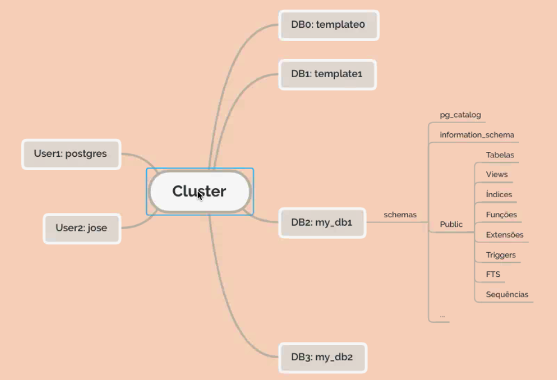

  Figura 1. Esquema básico do funcionamento de uma conexão Postgres.